# NOAA Data Analysis to Identify Weather Events That Are Most Harmful to Population Health and Generate Greatest Economic Consequences

### Plot the maximum damage amount by state (and split by event type if there are multiple maximum damages). Label each data point with event type and damage amount

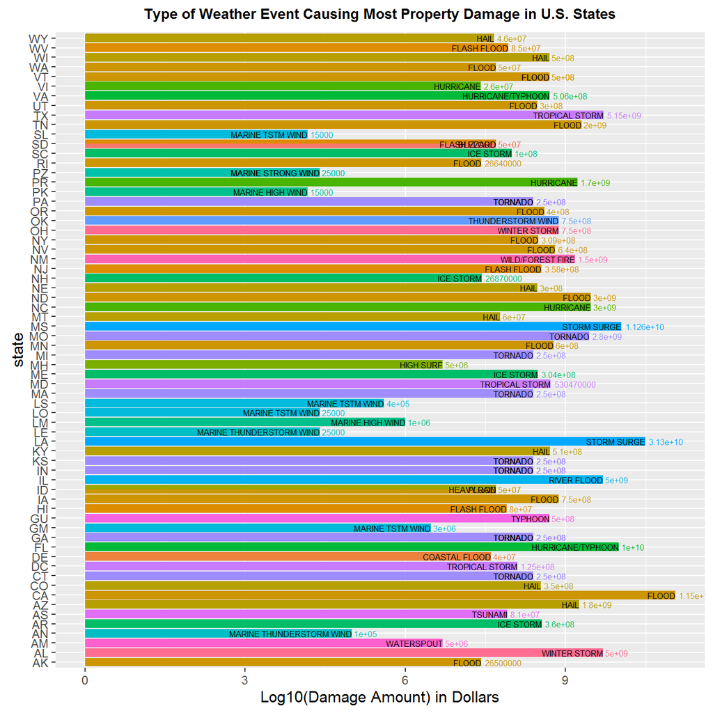

```r
library(ggplot2)

ggplot(maxdmg, aes(state, log10(prodmgamt))) + geom_bar(stat = "identity", aes(fill = etype), position = "dodge") + ylab("Log10(Damage Amount) in Dollars") + coord_flip() + geom_text(data=maxdmg,aes(label=etype), vjust=0.5, hjust=1,size = 2) + geom_text(data=maxdmg,aes(label=prodmgamt, color = etype),vjust=0.5, hjust=-0.1, size = 2) + ggtitle("Type of Weather Event Causing Most Property Damage in U.S. States") + theme(plot.title = element_text(size=10, face="bold", margin = margin(0, 0, 10, 0)), legend.position = "none")
```

```r
# legend.position = "none" removes the figure legend as it is no longer needed
```

## Conclusion

The NOAA data is useful in finding out what type of weather events are causing most property damage in each U.S. state, despite the fact that there are many missing, incomplete or mis-annotated data points. A preliminary analysis performed above shows that weather events do causing large amount of property damage across the U.S. For example, in California (CA), the worst single flooding event caused around 115000000000 dollars of property damage.

## I am skipping the rest of the analysis requirement as they would be performed and plotted similarly to the above, and I am short on time